# MSMB-Chap12: Supervised Learning

## Topics

- linear discriminant analysis
- overfitting & the curse of dimensionality
- measures of performance
- cross-validation
- regularization and variable selection
- method hacking

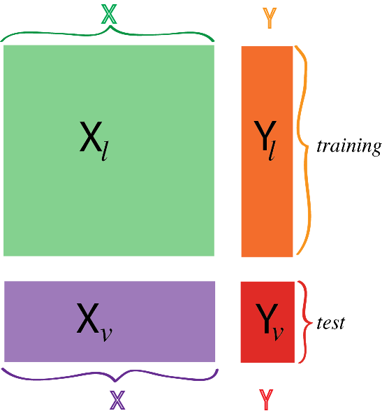

# Linear discrimination analysis

The diabetes dataset (Reaven and Miller 1979) presents three different groups of diabetes patients and five clinical variables measured on them. Let’s see whether we can predict the group from the insulin and glutest variables in the diabetes data.

```r
library("readr")
library("magrittr")
diabetes = read_csv("diabetes.csv", col_names = TRUE)
diabetes
```

| id | relwt | glufast | glutest | steady | insulin | group |
| --- | --- | --- | --- | --- | --- | --- |
| 1 | 0.81 | 80 | 356 | 124 | 55 | 3 |
| 3 | 0.94 | 105 | 319 | 143 | 105 | 3 |
| 5 | 1.00 | 90 | 323 | 240 | 143 | 3 |
| 7 | 0.91 | 100 | 350 | 221 | 119 | 3 |
| 9 | 0.99 | 97 | 379 | 142 | 98 | 3 |
| 11 | 0.90 | 91 | 353 | 221 | 53 | 3 |
| 13 | 0.96 | 78 | 290 | 136 | 142 | 3 |
| 15 | 0.74 | 86 | 312 | 208 | 68 | 3 |
| 17 | 1.10 | 90 | 364 | 152 | 76 | 3 |
| 19 | 0.83 | 85 | 296 | 116 | 60 | 3 |

[output cut: 134 more lines]

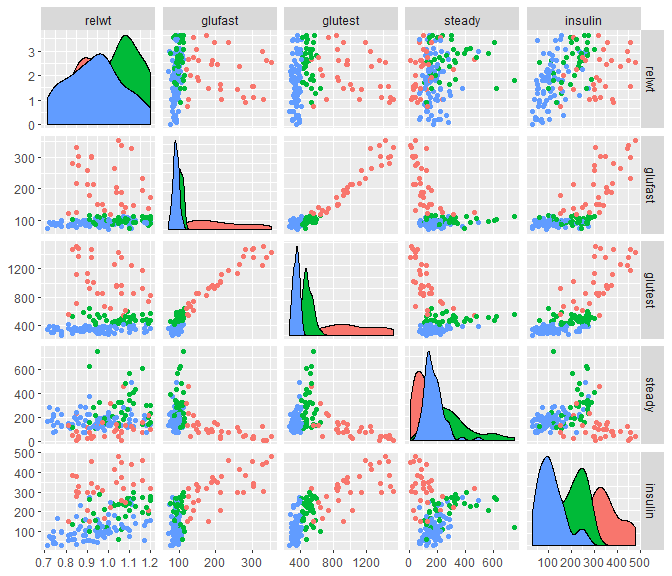

```r
diabetes$group %<>% factor

library("GGally")
ggpairs(diabetes, mapping = aes(col = group),
   columns = 2:6,upper = list(continuous = "points"), progress=FALSE)
```

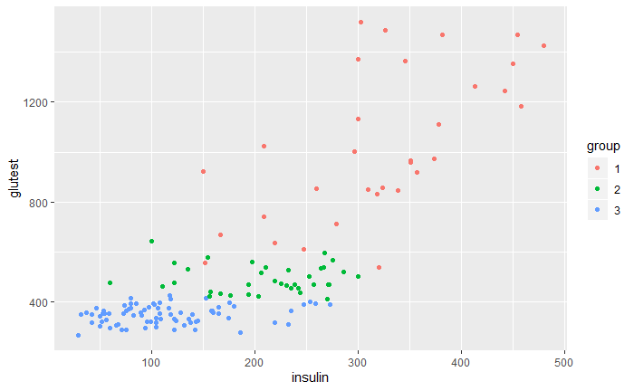

```r
ggdb = ggplot(mapping = aes(x = insulin, y = glutest)) +
  geom_point(aes(colour = group), data = diabetes)
ggdb
```

```r
library("MASS")
diabetes_lda = lda(group ~ insulin + glutest, data = diabetes)
diabetes_lda
```

```
Call:
lda(group ~ insulin + glutest, data = diabetes)

Prior probabilities of groups:
        1         2         3
0.2222222 0.2500000 0.5277778

Group means:
   insulin   glutest
1 320.9375 1027.3750
2 208.9722  493.9444
3 114.0000  349.9737

Coefficients of linear discriminants:
                 LD1         LD2
insulin -0.004463900 -0.01591192
glutest -0.005784238  0.00480830

Proportion of trace:
   LD1    LD2
0.9677 0.0323
```

```r
ghat = predict(diabetes_lda)$class
table(ghat, diabetes$group)
```

```
ghat  1  2  3
   1 25  0  0
   2  6 24  6
   3  1 12 70
```

```r
mcr= mean(ghat != diabetes$group)
mcr
```

```
[1] 0.1736111
```

> Linear discriminat analyis is using Bayes’ Theorem for classification. (Source: An Introduction to Statistical Learning; Gareth James, Daniela Witten, Trevor Hastie and Robert Tibshirani; 2017)

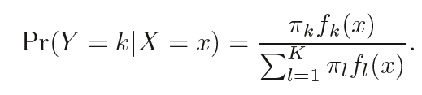

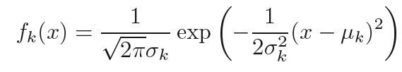

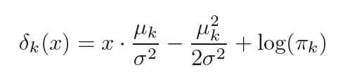

```r
make1Dgrid = function(x) {
  rg = grDevices::extendrange(x)
  seq(from = rg[1], to = rg[2], length.out = 100)
}

diabetes_grid = with(diabetes,
  expand.grid(insulin = make1Dgrid(insulin),
              glutest = make1Dgrid(glutest)))

diabetes_grid$ghat =
  predict(diabetes_lda, newdata = diabetes_grid)$class

head(diabetes_grid)
```

|  | insulin | glutest | ghat |
| --- | --- | --- | --- |
| 1 | 6.45000 | 206.45 | 3 |
| 2 | 11.46111 | 206.45 | 3 |
| 3 | 16.47222 | 206.45 | 3 |
| 4 | 21.48333 | 206.45 | 3 |
| 5 | 26.49444 | 206.45 | 3 |
| 6 | 31.50556 | 206.45 | 3 |

```r
diabetes_lda$scaling
```

```
                 LD1         LD2
insulin -0.004463900 -0.01591192
glutest -0.005784238  0.00480830
```

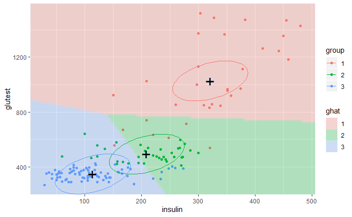

```r
#https://www.fbbva.es/wp-content/uploads/2017/05/dat/greenacre_c11_2010.pdf
centers = diabetes_lda$means

unitcircle = exp(1i * seq(0, 2*pi, length.out = 90)) %>%
          {cbind(Re(.), Im(.))}
ellipse = unitcircle %*% solve(diabetes_lda$scaling)

ellipses = lapply(seq_len(nrow(centers)), function(i) {
  (ellipse +
   matrix(centers[i, ], byrow = TRUE,
          ncol = ncol(centers), nrow = nrow(ellipse))) %>%
     cbind(group = i)
}) %>% do.call(rbind, .) %>% data.frame
ellipses$group %<>% factor

ggdb + geom_raster(aes(fill = ghat),
            data = diabetes_grid, alpha = 0.25, interpolate = TRUE) +
    geom_point(data = as_tibble(centers), pch = "+", size = 8) +
    geom_path(aes(colour = group), data = ellipses) +
    scale_x_continuous(expand = c(0, 0)) +
    scale_y_continuous(expand = c(0, 0))
```

What happens if we use not only `insuline` and `glutest` **(MCR=17.4 %)**, but all features?

```r
diabetes_lda5 = lda(group ~ relwt + glufast + glutest +
                    steady + insulin, data = diabetes)
diabetes_lda5
```

```
Call:
lda(group ~ relwt + glufast + glutest + steady + insulin, data = diabetes)

Prior probabilities of groups:
        1         2         3
0.2222222 0.2500000 0.5277778

Group means:
      relwt   glufast   glutest   steady  insulin
1 0.9915625 213.65625 1027.3750 108.8438 320.9375
2 1.0558333  99.30556  493.9444 288.0000 208.9722
3 0.9372368  91.18421  349.9737 172.6447 114.0000

Coefficients of linear discriminants:
                  LD1           LD2
relwt   -1.339546e+00 -3.7950612048
glufast  3.301944e-02  0.0373202882
glutest -1.263978e-02 -0.0068947755
steady   1.240248e-05 -0.0059924778
insulin -3.895587e-03  0.0005754322

Proportion of trace:
   LD1    LD2
0.8784 0.1216
```

```r
ghat5 = predict(diabetes_lda5)$class
table(ghat5, diabetes$group)
```

```
ghat5  1  2  3
    1 26  0  0
    2  5 31  3
    3  1  5 73
```

```r
mcr.all= mean(ghat5 != diabetes$group)
```

Now we get a **MCR= 9.72 %** - an improvement?

# Machine learning vs rote learning

The central goal in statistical learning, however, is **generalizability**. We want an algorithm that is able to generalize, i.e., interpolate and extrapolate from given data to make good predictions about future data.

A “learn-by-heart” illustrating example:

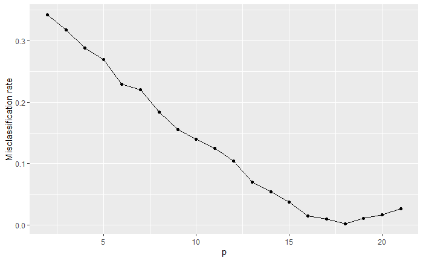

Make your model complex enough to fit anything?

> Well, our model performance was evaluated on the same data on which it has been trained - **bad idea**!

# Cross-validation

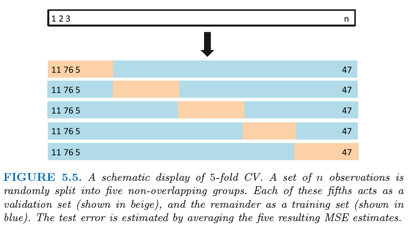

(Source: An Introduction to Statistical Learning; Gareth James, Daniela Witten, Trevor Hastie and Robert Tibshirani; 2017)

The key idea is to assess model performance on different data than those on which the model was trained.

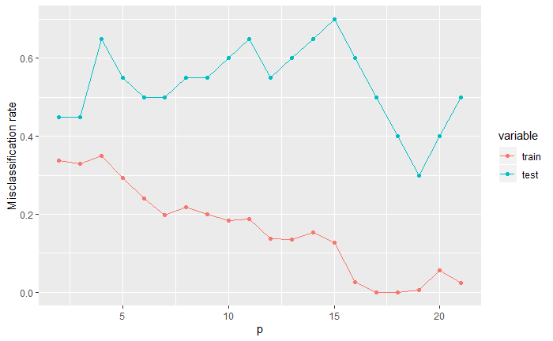

```r
estimate_mcl_loocv = function(x, resp) {
  vapply(seq_len(nrow(x)), function(i) {
    fit  = lda(x[-i, ], resp[-i])
    ptrn = predict(fit, newdata = x[-i,, drop = FALSE])$class
    ptst = predict(fit, newdata = x[ i,, drop = FALSE])$class
    c(train = mean(ptrn != resp[-i]), test = (ptst != resp[i]))
  }, FUN.VALUE = numeric(2)) %>% rowMeans %>% t %>% as_tibble
}

xmat = matrix(rnorm(n * last(p)), nrow = n)
resp = sample(c("apple", "orange"), n, replace = TRUE)

mcl = lapply(p, function(k) {
  estimate_mcl_loocv(xmat[, 1:k], resp)
}) %>% bind_rows %>% data.frame(p) %>% melt(id.var = "p")

ggplot(mcl, aes(x = p, y = value, col = variable)) + geom_line() +
  geom_point() + ylab("Misclassification rate")
```

So far we have used random data, what happens if we apply data with relevant class seperation?

```r
p   = 2:20
mcl = replicate(1, {
  xmat = matrix(rnorm(n * last(p)), nrow = n)
  resp = sample(c("apple", "orange"), n, replace = TRUE)
  xmat[, 1:6] = xmat[, 1:6] + as.integer(factor(resp))

  lapply(p, function(k) {
    estimate_mcl_loocv(xmat[, 1:k], resp)
  }) %>% bind_rows %>% cbind(p = p) %>% melt(id.var = "p")
}, simplify = FALSE) %>% bind_rows
```

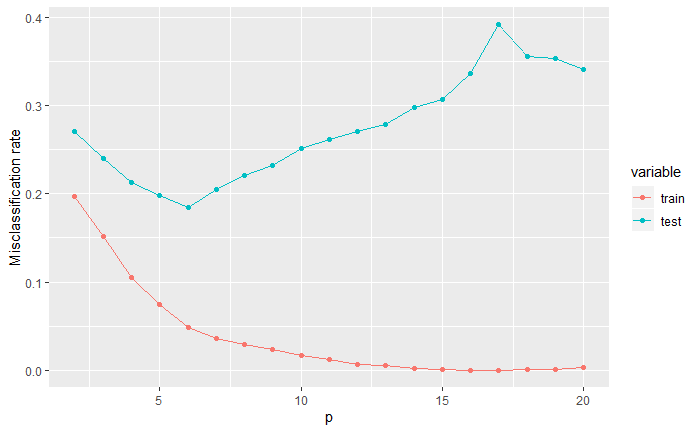

```r
mcl =  group_by(mcl, p, variable) %>%
   summarise(value = mean(value))

ggplot(mcl, aes(x = p, y = value, col = variable)) + geom_line() +
   geom_point() + ylab("Misclassification rate")
```

$\text{MSE} = \underbrace{\text{Var}(\hat{Y})}_{\text{variance}} + \underbrace{\mathbb{E}[\hat{Y}-Y]^2}_{\text{bias}}$

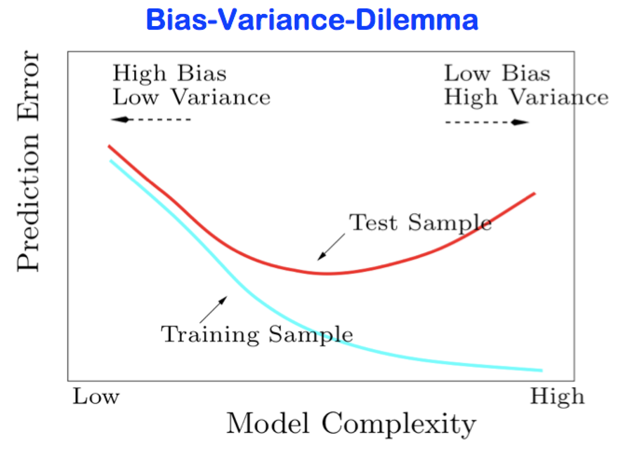

Idealized version of Figure 12.13, from Hastie, Tibshirani, and Friedman (2008).

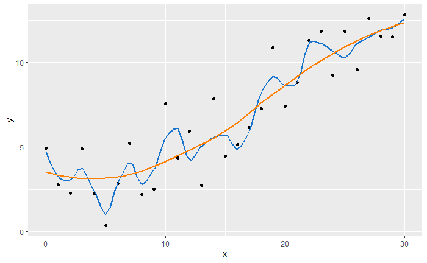

```r
library(ggplot2); library(tidyverse)
ov = tibble(
  x = seq(0, 30, by = 1),
  y = 2 + 0.01 * x^2 + 0.1 * x + 2 * rnorm(length(x)))
ggplot(ov, aes(x = x, y = y)) +
  geom_point() +
  geom_smooth(span = 0.2, col = "dodgerblue3", se = FALSE) +
  geom_smooth(span = 0.8, col = "darkorange1", se = FALSE)
```

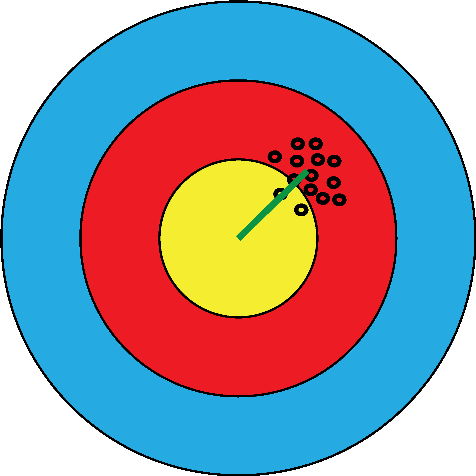

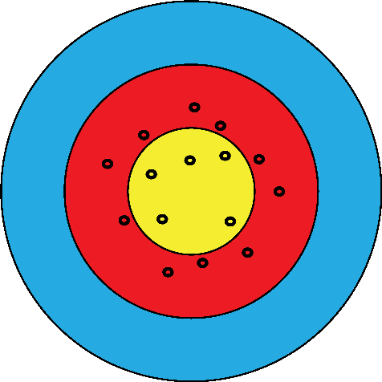

In applications, we often only get one shot, therefore being reliably almost on target can beat being right on the long term average but really off today.

## Objective function, cost function, risk function

**misclassification rate:**

$\widehat{\text{MCR}} = \frac{1}{n}\sum_{i=1}^n 𝟙_{\hat{y_i} \neq y_i}.$

For finding rare events: **Jaccard index**

$J(A,B) = \frac{|\,A\cap B\,|}{|\,A\cup B\,|}$

**probabilistic** class predictions:

$\log \text{loss} = -\frac{1}{n}\sum_{i=1}^n y_i\log(\hat{p}_i) + (1 - y_i)\log(1 - \hat{p}_i)$

For continuous continuous response variables (regression): **mean squared error**

$\widehat{\text{MSE}} = \frac{1}{n}\sum_{i=1}^n ( \hat{Y}_i - Y_i )^2$

# curse of dimensionality

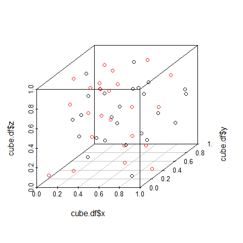

```r
n = 50
cube.df = tibble(
  s = rep(c(1,2),25),
  x = runif(n),
  y = runif(n),
  z = runif(n) )

scatterplot3d::scatterplot3d(x=cube.df$x,y=cube.df$y,z=cube.df$z,color = cube.df$s)
```

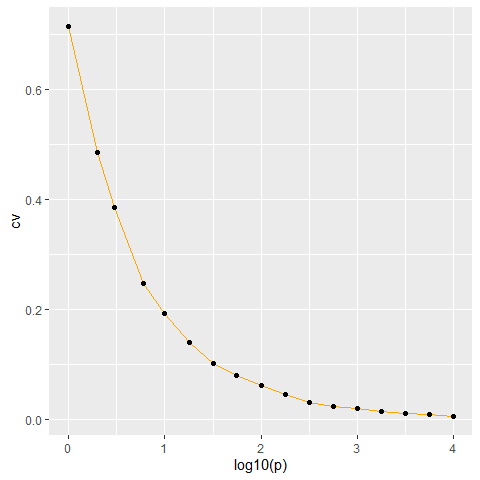

```r
n = 1000
df = tibble(
  p = round(10 ^ seq(0, 4, by = 0.25)),
  cv = vapply(p, function(k) {
    x1 = matrix(runif(k * n), nrow = n)
    x2 = matrix(runif(k * n), nrow = n)
    d = sqrt(rowSums((x1 - x2)^2))
    sd(d) / mean(d)
  }, FUN.VALUE = numeric(1)))
ggplot(df, aes(x = log10(p), y = cv)) + geom_line(col = "orange") +
  geom_point()
```

Coefficient of variation (CV) of the distance between randomly picked points in the unit hypercube, as a function of the dimension. As the dimension increases, everybody is equally far away from everyone else: there is almost no variation in the distances any more.

# Penalization the use of elastic net = lasso + ridge

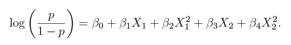

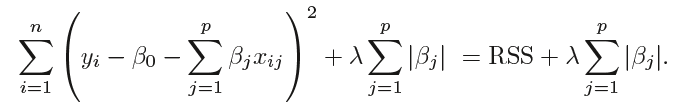

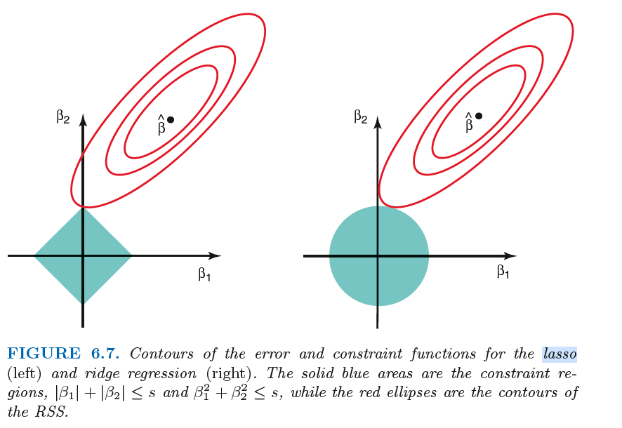

(Source: An Introduction to Statistical Learning; Gareth James, Daniela Witten, Trevor Hastie and Robert Tibshirani; 2017)

> Example: predicting colon cancer from stool microbiome composition

Zeller et al. (2014) studied metagenome **sequencing data from fecal samples of 156 humans** that included colorectal cancer patients and tumor-free controls. Their aim was to see whether they could identify biomarkers (presence or abundance of certain taxa) that could help with early tumor detection.

[figure not shown]

```r
suppressMessages(library("ExperimentHub"))
eh = ExperimentHub()
```

```
snapshotDate(): 2019-04-29
```

```r
eh
```

```
ExperimentHub with 2220 records
# snapshotDate(): 2019-04-29
# $dataprovider: Eli and Edythe L. Broad Institute of Harvard and MIT, NA, GEO, Department of Psychology, Abdul Haq Campus, Federal Urd...
# $species: Homo sapiens, Mus musculus, Saccharomyces cerevisiae, human gut metagenome, Saccharomyces cerevisiae S288C, groundwater met...
# $rdataclass: ExpressionSet, SummarizedExperiment, SummarizedBenchmark, RaggedExperiment, data.frame, character, DataFrame, list, Sing...
# additional mcols(): taxonomyid, genome, description, coordinate_1_based, maintainer, rdatadateadded, preparerclass, tags,
#   rdatapath, sourceurl, sourcetype
# retrieve records with, e.g., 'object[["EH1"]]'

           title
  EH1    | RNA-Sequencing and clinical data for 7706 tumor samples from The Cancer Genome Atlas
  EH166  | ERR188297
  EH167  | ERR188088
  EH168  | ERR188204
  EH169  | ERR188317
  ...      ...
  EH2539 | LAML_GISTIC_Peaks-20160128
  EH2540 | LAML_GISTIC_ThresholdedByGene-20160128
  EH2541 | SKCM_GISTIC_AllByGene-20160128
  EH2542 | SKCM_GISTIC_Peaks-20160128
  EH2543 | SKCM_GISTIC_ThresholdedByGene-20160128
```

```r
zeller = eh[["EH361"]]
```

[output not shown]

```r
table(zeller$disease)
```

```
       cancer large_adenoma             n small_adenoma
           53            15            61            27
```

```r
zellerNC = zeller[, zeller$disease %in% c("n", "cancer")]

pData(zellerNC)[ sample(ncol(zellerNC), 3), ]
```

|  | subjectID | age | gender | bmi | country | disease | tnm_stage | ajcc_stage | localization | fobt | wif-1_gene_methylation_test | group | bodysite | ethnicity | number_reads |
| --- | --- | --- | --- | --- | --- | --- | --- | --- | --- | --- | --- | --- | --- | --- | --- |
| CCIS07648107ST-4-0 | FR-053 | 62 | female | 21 | france | n | NA | NA | NA | negative | negative | control | stool | white | 66245949 |
| CCIS16326685ST-4-0 | FR-542 | 46 | female | 29 | france | n | NA | NA | NA | negative | negative | control | stool | white | 53344597 |
| CCIS52370277ST-4-0 | FR-827 | 53 | male | 25 | france | cancer | t4n1m1 | iv | lc | negative | positive | crc | stool | white | 56128839 |

```r
as_tibble(Biobase::exprs(zellerNC)[c(510, 527), 1:2], rownames="phyla")
```

| phyla | CCIS00146684ST-4-0 | CCIS00281083ST-3-0 |
| --- | --- | --- |
| k__Bacteria\|p__Firmicutes\|c__Negativicutes\|o__Selenomonadales\|f__Veillonellaceae\|g__Dialister\|s__Dialister_invisus\|t__GCF_000160055 | 0 | 0 |
| k__Bacteria\|p__Firmicutes\|c__Clostridia\|o__Clostridiales\|f__Clostridiaceae\|g__Clostridium\|s__Clostridium_symbiosum\|t__Clostridium_symbiosum_unclassified | 0 | 0 |

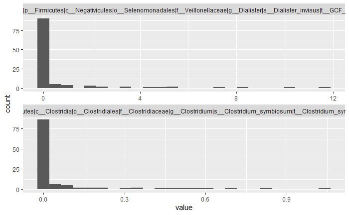

```r
ggplot(melt(Biobase::exprs(zellerNC)[c(510, 527), ]), aes(x = value)) +
    geom_histogram(bins = 25) +
    facet_wrap( ~ Var1, ncol = 1, scales = "free")
```

```r
suppressMessages(library("glmnet"))
glmfit = glmnet(x = t(Biobase::exprs(zellerNC)),
                y = factor(zellerNC$disease),
                family = "binomial",alpha=1)
summary(glmfit)
```

```
           Length Class     Mode
a0            100 -none-    numeric
beta       150500 dgCMatrix S4
df            100 -none-    numeric
dim             2 -none-    numeric
lambda        100 -none-    numeric
dev.ratio     100 -none-    numeric
nulldev         1 -none-    numeric
npasses         1 -none-    numeric
jerr            1 -none-    numeric
offset          1 -none-    logical
classnames      2 -none-    character
call            5 -none-    call
nobs            1 -none-    numeric
```

```r
library(RColorBrewer)
predTrsf = predict(glmfit, newx = t(Biobase::exprs(zellerNC)),
                   type = "class", s = 0.04)
table(predTrsf, zellerNC$disease)
```

```
predTrsf cancer  n
  cancer     51  0
  n           2 61
```

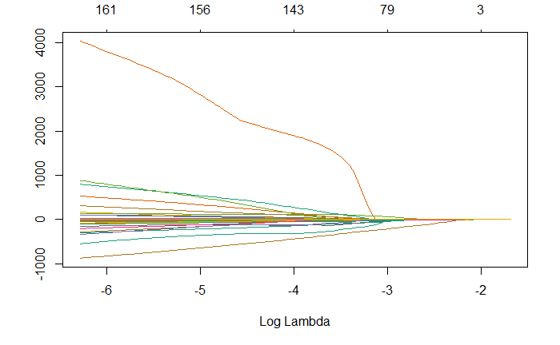

```r
plot(glmfit, col = brewer.pal(8, "Dark2"), lwd = sqrt(3), ylab = "", xvar="lambda")
```

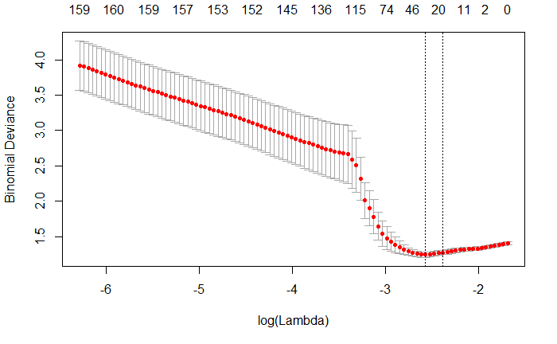

```r
cvglmfit = cv.glmnet(x = t(Biobase::exprs(zellerNC)),
                     y = factor(zellerNC$disease),
                     family = "binomial")
plot(cvglmfit)
```

```r
cvglmfit$lambda.min
```

```
[1] 0.07680558
```

```r
cvglmfit$lambda.1se
```

```
[1] 0.09251259
```

Diagnostic plot for cv.glmnet: shown is a measure of cross-validated prediction performance, the deviance, as a function of λ. The dashed vertical lines show lambda.min and lambda.1se.

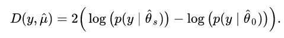

Source: Wikipedia

```r
s0 = cvglmfit$lambda.1se
predict(glmfit, newx = t(Biobase::exprs(zellerNC)),type = "class", s = s0) %>%
    table(zellerNC$disease)
```

```
.        cancer  n
  cancer     37  5
  n          16 56
```

```r
coefs = coef(glmfit)[, which.min(abs(glmfit$lambda - s0))]
topthree = order(abs(coefs), decreasing = TRUE)[1:3]
as.vector(coefs[topthree])
```

```
[1] -57.014555  -7.648021  -1.352843
```

```r
names(coefs)[topthree]
```

```
[1] "k__Bacteria|p__Candidatus_Saccharibacteria|c__Candidatus_Saccharibacteria_noname|o__Candidatus_Saccharibacteria_noname|f__Candidatus_Saccharibacteria_noname|g__Candidatus_Saccharibacteria_noname|s__candidate_division_TM7_single_cell_isolate_TM7b"
[2] "k__Bacteria|p__Firmicutes|c__Clostridia|o__Clostridiales|f__Ruminococcaceae|g__Subdoligranulum|s__Subdoligranulum_variabile"
[3] "k__Bacteria|p__Firmicutes|c__Clostridia|o__Clostridiales|f__Lachnospiraceae|g__Lachnospiraceae_noname|s__Lachnospiraceae_bacterium_7_1_58FAA"
```

## Forward-Selection with Orthogonalized Regressors

Gram-Schmidtorthogonalization helps to mitigate the **collinearity** problem by detecting and removing redundant variables. (Chen et al.,1989; Stoppiglia et al., 2003; Guyon et al., 2003)

**procedure** (Stoppiglia et al., 2003):

- select feature that best explains response variable, eg.:

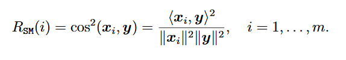

- apply Gram-Schmidt orthogonalization on remainin features

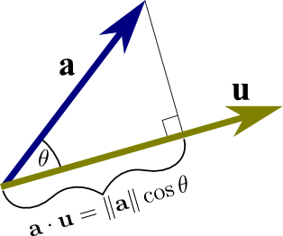

- repeat process til stopping critera is met

# Method hacking

- a large choice of methods -> CRAN task view Machine Learning & Statistical Learning
- challenging heterogeneity of tuning parameter interfaces -> caret package
- R & Tensorflow

In Chapter 6 we encountered p-value hacking. A similar phenomenon exists in statistical learning: given a dataset, we explore various different methods of preprocessing (such as normalization, outlier detection, transformation, feature selection), try out different machine learning algorithms and tune their parameters until we are content with the result. The measured accuracy is likely to be too optimistic, i.e., will not generalize to a new dataset. Embedding as many of our methodical choices into a computational formalism and having an **outer cross-validation** loop (not to be confused with the inner loop that does the parameter tuning) will ameliorate the problem. But is unlikely to address it completely, since not all our choices can be formalized.

The gold standard remains **validation on truly unseen data**. In addition, it is never a bad thing if the classifier is not a black box but can be **interpreted in terms of domain knowledge**. Finally, report not just summary statistics, such as misclassification rates, but lay open the complete **computational workflow**, so that anyone (including your future self) can convince themselves of the robustness of the result or of the influence of the preprocessing, model selection and tuning choices (Holmes 2018).